# R Review & Assessment

We can also fit a linear model to the same relationship:

```r
mod <- lm(price ~ carat, data = diamonds)
```

Above, we saved our linear model to a variable named `mod` so we can use it later. We can look at the result of model fitting with `summary`.

```r
summary(mod)
```

```
##
## Call:
## lm(formula = price ~ carat, data = diamonds)
##
## Residuals:
##      Min       1Q   Median       3Q      Max
## -18585.3   -804.8    -18.9    537.4  12731.7
##
## Coefficients:
##             Estimate Std. Error t value Pr(>|t|)
## (Intercept) -2256.36      13.06  -172.8   <2e-16 ***
## carat        7756.43      14.07   551.4   <2e-16 ***
## ---
## Signif. codes:  0 '***' 0.001 '**' 0.01 '*' 0.05 '.' 0.1 ' ' 1
##
## Residual standard error: 1549 on 53938 degrees of freedom
## Multiple R-squared:  0.8493, Adjusted R-squared:  0.8493
## F-statistic: 3.041e+05 on 1 and 53938 DF,  p-value: < 2.2e-16
```

And we can also plot the line of best fit on the scatterplot:

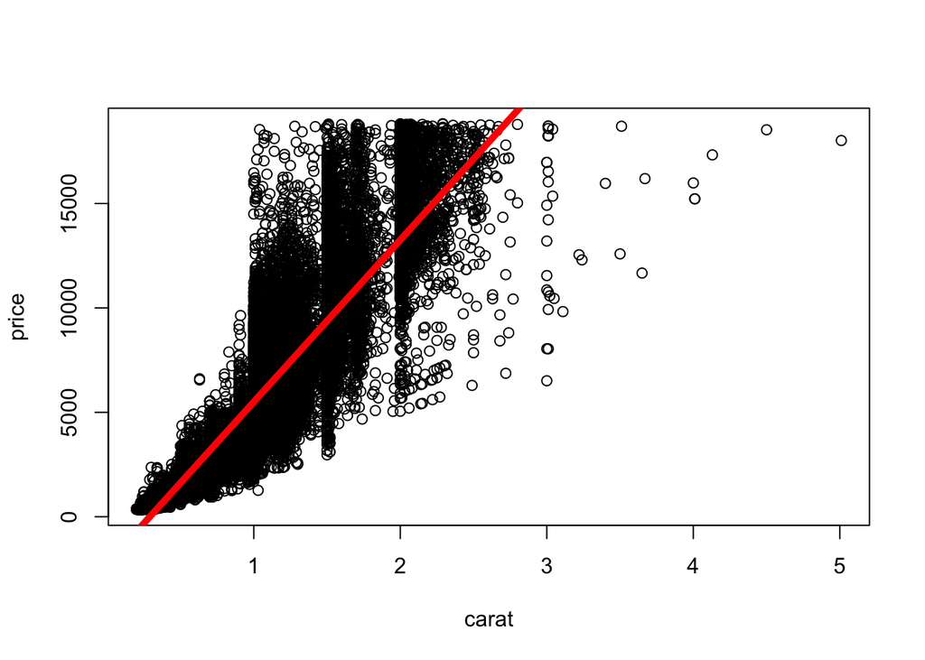

```r
plot(price ~ carat, data = diamonds)
abline(mod$coefficients[[1]], mod$coefficients[[2]], col = "red", lwd = 5)
```

### More advanced topics to cover if time allows:

- Modeling
- `sample` / `runif` / `rnorm`
  - sampling a data.frame
- Common util functions
  - `table`
- Iteration
  - `for` loops
    - When do we use for loops?
  - `while` loops
- apply-family
- `sapply`
- `lapply`
- functions: We’ll skip this as it will be taught in another lesson
- Writing faster code
- What is ‘vectorization’?
- Don’t grow variables
- Debugging
- traceback()
- browser()
- breakpoints in RStudio

## Call your shot

An excellent way to really learn a programming language is to call out what the result of running some expression will be *before* you run it. Afterwards, you can compare your expectation with what actually happened.

Here are code chunks with a series of expressions. Try to predict what **the final expression* does before running the entire chunk and add a note if you got one wrong.

```r
x <- 2
x ^ 2
```

```
## [1] 4
```

```r
x <- 1; y <- 2; x + y;
```

```
## [1] 3
```

```r
x <- "hello"
y <- "world"
paste(x, y)
```

```
## [1] "hello world"
```

```r
x <- list(1, 2, 3)
y <- list(4, 5, 6)
z <- c(x, y)
length(z)
```

```
## [1] 6
```

```r
x <- data.frame(x = 1:6)
y <- data.frame(x = 1:7)
z <- rbind(x, y)
nrow(z)
```

```
## [1] 13
```

```r
x <- NA

if (is.na(x)) {
  print("foo")
} else {
  print("bar")
}
```

```
## [1] "foo"
```

```r
numbers <- seq(1, 10)

for (number in numbers) {
  if (number %% 2){
    print(number)
  }
}
```

```
## [1] 1
## [1] 3
## [1] 5
## [1] 7
## [1] 9
```

```r
x <- 10

while (x >= 0) {
  print(x)

  if (x == 5) {
    break
  }

  x <- x - 1
}
```

```
## [1] 10
## [1] 9
## [1] 8
## [1] 7
## [1] 6
## [1] 5
```

```r
x <- c(1, "2", 3)
class(x)
```

```
## [1] "character"
```

```r
x <- list(1, 2, 3)
lapply(x, cumsum)
```

```
## [[1]]
## [1] 1
##
## [[2]]
## [1] 2
##
## [[3]]
## [1] 3
```

```r
x <- data.frame(letter = LETTERS)
class(x[1,])
```

```
## [1] "factor"
```

```r
x <- data.frame(letter = LETTERS)
class(x[1, 1, drop = FALSE])
```

```
## [1] "data.frame"
```

```r
x <- data.frame(x = 1)
y <- data.frame(x = 2)
z <- rbind(x[1,1], y[1,1])
class(z)
```

```
## [1] "matrix"
```

```r
rep(TRUE, 5) & rep(FALSE, 5)
```

```
## [1] FALSE FALSE FALSE FALSE FALSE
```

```r
rep(TRUE, 5) && rep(FALSE, 5)
```

```
## [1] FALSE
```

```r
x <- c(1, 2, 3)
y <- c("A", "B", "C")
z <- c(x, y)
class(z)
```

```
## [1] "character"
```

```r
x <- c(1, 2, NA, 4, NA)
length(is.na(x))
```

```
## [1] 5
```

```r
x <- c(1, NA, 3)
y <- c(NA, 2, NA)
all(is.na(x + y))
```

```
## [1] TRUE
```

## Summary

By the end of this lesson, you should have feel touched up on your general R skills and you also should have seen some of the trickier parts of R. Hopefully having seen the trickier parts of R will help later on down the road.

## Resources

Other good resources:

- One of our lessons on R: https://github.nceas.ucsb.edu/Training/R-intro
- Great, free book: http://r4ds.had.co.nz/
- DataCamp’s R intro, https://www.datacamp.com/courses/free-introduction-to-r Sources:
- Used https://www.rstudio.com/resources/cheatsheets/ to make sure I wasn’t missing any basic stuff